# R Notebook

Problem statement:

Loading all required library

```r
library(moments) #skewness
library(pastecs) #descriptive statistics stats.desc
library(diptest) # Hartigans' dip test for unimodality
library(fmsb) #VIF
library(DAAG) #K-fold validation
library(ggplot2)
```

Data import Initial setwd command will set current working directory. The file in the format of csv(comma separated version) loaded to R in data.frame format. str command will give observation,data type, name, few sample of variables.

Attribute Information:

```r
# data mining
setwd("/home/sudhir/git/ML-R/OLS project/Cement")
data=read.csv('train.csv')
str(data)
```

```
'data.frame':   518 obs. of  9 variables:
 $ Cement             : num  199 500 156 230 159 ...
 $ Slag               : num  132 0 178 0 209 ...
 $ Ash                : num  0 0 187 118 161 ...
 $ Water              : num  192 151 221 195 201 ...
 $ Superplasticizer   : num  0 9 7 4.63 7 ...
 $ CoarseAggregate    : num  978 1033 854 1029 848 ...
 $ FineAggregate      : num  826 655 614 759 669 ...
 $ Days               : Factor w/ 3 levels "H","L","M": 3 3 3 3 3 3 3 3 3 3 ...
 $ CompressiveStrength: num  28 69.8 29.4 24.5 30.9 ...
```

```r
head(data)
```

|  | Cement | Slag | Ash | Water | Superplasticizer | CoarseAggregate | FineAggregate | Days | CompressiveStrength |
| --- | --- | --- | --- | --- | --- | --- | --- | --- | --- |
| 1 | 199 | 132 | 0 | 192 | 0.00 | 978 | 826 | M | 28.0 |
| 2 | 500 | 0 | 0 | 151 | 9.00 | 1033 | 655 | M | 69.8 |
| 3 | 156 | 178 | 187 | 221 | 7.00 | 854 | 614 | M | 29.4 |
| 4 | 230 | 0 | 118 | 195 | 4.63 | 1029 | 759 | M | 24.5 |
| 5 | 159 | 209 | 161 | 201 | 7.00 | 848 | 669 | M | 30.9 |
| 6 | 450 | 50 | 0 | 200 | 3.00 | 1124 | 613 | M | 39.4 |

Finding missing value “NA” using “is.na()”.

```r
# Checking missing value
summary(is.na(data)) # Column wise summary
```

```
   Cement           Slag            Ash            Water         Superplasticizer
 Mode :logical   Mode :logical   Mode :logical   Mode :logical   Mode :logical
 FALSE:518       FALSE:518       FALSE:518       FALSE:518       FALSE:518
 NA's :0         NA's :0         NA's :0         NA's :0         NA's :0
 CoarseAggregate FineAggregate      Days         CompressiveStrength
 Mode :logical   Mode :logical   Mode :logical   Mode :logical
 FALSE:518       FALSE:518       FALSE:518       FALSE:518
 NA's :0         NA's :0         NA's :0         NA's :0
```

```r
table(is.na(data)) # Total summary
```

```
FALSE
 4662
```

Measure of central tendency of data.

```r
summary(data)# M.o.CT
```

```
     Cement         Slag          Ash          Water     Superplasticizer
 Min.   :102   Min.   :  0   Min.   :  0   Min.   :122   Min.   : 0.0
 1st Qu.:178   1st Qu.:  0   1st Qu.:  0   1st Qu.:170   1st Qu.: 0.0
 Median :266   Median : 22   Median :  0   Median :186   Median : 6.0
 Mean   :273   Mean   : 77   Mean   : 57   Mean   :183   Mean   : 6.0
 3rd Qu.:339   3rd Qu.:148   3rd Qu.:118   3rd Qu.:193   3rd Qu.:10.0
 Max.   :540   Max.   :359   Max.   :200   Max.   :237   Max.   :32.2
 CoarseAggregate FineAggregate Days    CompressiveStrength
 Min.   : 801    Min.   :594   H: 91   Min.   : 5.0
 1st Qu.: 916    1st Qu.:723   L:120   1st Qu.:23.9
 Median : 966    Median :778   M:307   Median :32.9
 Mean   : 967    Mean   :771           Mean   :34.7
 3rd Qu.:1028    3rd Qu.:820           3rd Qu.:43.2
 Max.   :1134    Max.   :993           Max.   :81.8
```

```r
stat.desc(data)# M.o.CT +M.o.V
```

|  | Cement | Slag | Ash | Water | Superplasticizer | CoarseAggregate | FineAggregate | Days | CompressiveStrength |
| --- | --- | --- | --- | --- | --- | --- | --- | --- | --- |
| nbr.val | 5.18e+02 | 518.00 | 518.00 | 5.18e+02 | 518.000 | 5.18e+02 | 5.18e+02 | NA | 5.18e+02 |
| nbr.null | 0.00e+00 | 236.00 | 277.00 | 0.00e+00 | 190.000 | 0.00e+00 | 0.00e+00 | NA | 0.00e+00 |
| nbr.na | 0.00e+00 | 0.00 | 0.00 | 0.00e+00 | 0.000 | 0.00e+00 | 0.00e+00 | NA | 0.00e+00 |
| min | 1.02e+02 | 0.00 | 0.00 | 1.22e+02 | 0.000 | 8.01e+02 | 5.94e+02 | NA | 5.03e+00 |
| max | 5.40e+02 | 359.40 | 200.10 | 2.37e+02 | 32.200 | 1.13e+03 | 9.93e+02 | NA | 8.18e+01 |
| range | 4.38e+02 | 359.40 | 200.10 | 1.15e+02 | 32.200 | 3.33e+02 | 3.99e+02 | NA | 7.67e+01 |
| sum | 1.41e+05 | 39658.07 | 29522.53 | 9.49e+04 | 3088.934 | 5.01e+05 | 4.00e+05 | NA | 1.80e+04 |
| median | 2.66e+02 | 22.00 | 0.00 | 1.86e+02 | 6.000 | 9.66e+02 | 7.78e+02 | NA | 3.29e+01 |
| mean | 2.73e+02 | 76.56 | 56.99 | 1.83e+02 | 5.963 | 9.67e+02 | 7.71e+02 | NA | 3.47e+01 |
| SE.mean | 4.52e+00 | 3.90 | 2.87 | 8.71e-01 | 0.247 | 3.53e+00 | 3.37e+00 | NA | 6.74e-01 |

[output cut: 4 more lines]

A boxplot provides a graphical view of the median, quartiles, maximum, and minimum of a data set. Outlier is an observation point that is distant from other observations.

A histogram is a graphical representation of the distribution of numerical data. It is an estimate of the probability distribution of a continuous variable.To contruct histogram,the first step is to “bin” the range of values—that is, divide the entire range of values into a series of intervals—and then count how many values fall into each interval.

plot(density(data$…) will give distribution of data

Univariate analysis of “Cement” attribute

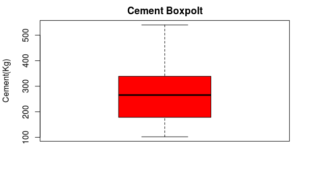

```r
new=data
boxplot(new$Cement, ylab='Cement(Kg)', main='Cement Boxpolt',col = 'red' )
```

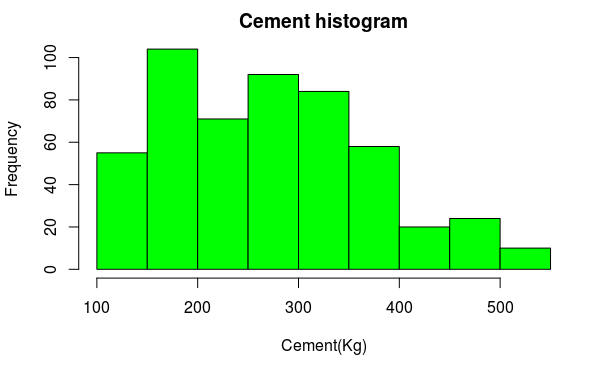

```r
hist(new$Cement, xlab='Cement(Kg)', main= 'Cement histogram', col='green')
```

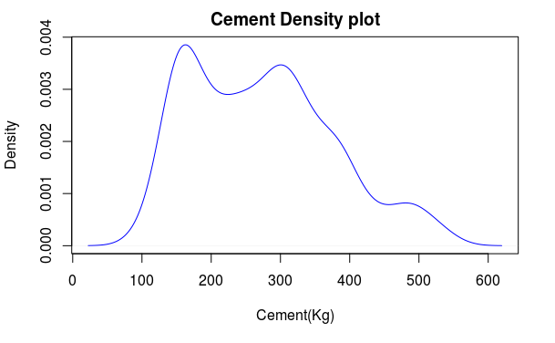

```r
plot(density(new$Cement), xlab='Cement(Kg)', main= 'Cement Density plot', col='blue')
```

```r
skewness(new$Cement)
```

```
[1] 0.496
```

```r
dip.test(new$Cement)
```

```
    Hartigans' dip test for unimodality / multimodality

data:  new$Cement
D = 0.03, p-value = 0.005
alternative hypothesis: non-unimodal, i.e., at least bimodal
```

Univariate analysis of “Slag(Kg)” attribute

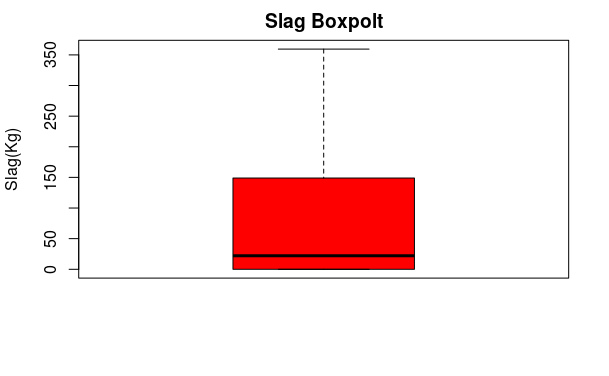

```r
boxplot( new$Slag, ylab='Slag(Kg)', main='Slag Boxpolt',col = 'red' )
```

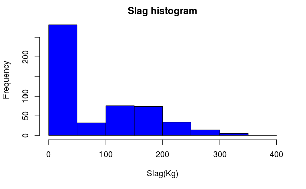

```r
hist(new$Slag, xlab='Slag(Kg)', main= 'Slag histogram', col='blue')
```

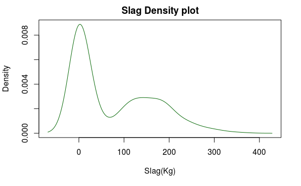

```r
plot(density(new$Slag), xlab='Slag(Kg)', main= 'Slag Density plot', col='darkgreen')
```

```r
skewness(new$Slag)
```

```
[1] 0.759
```

```r
dip.test(new$Slag)
```

```
    Hartigans' dip test for unimodality / multimodality

data:  new$Slag
D = 0.05, p-value <2e-16
alternative hypothesis: non-unimodal, i.e., at least bimodal
```

Univariate analysis of “Ash(Kg)” attribute

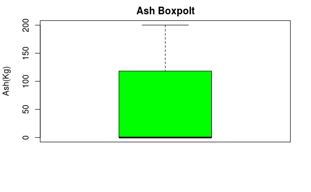

```r
boxplot( new$Ash, ylab='Ash(Kg)', main='Ash Boxpolt',col = 'green' )
```

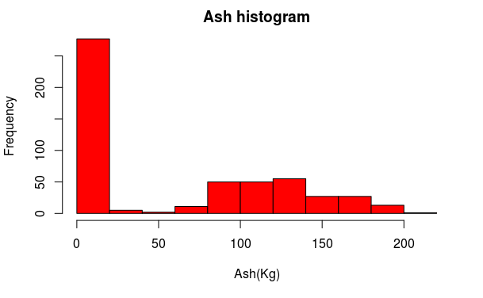

```r
hist(new$Ash, xlab='Ash(Kg)', main= 'Ash histogram', col='red')
```

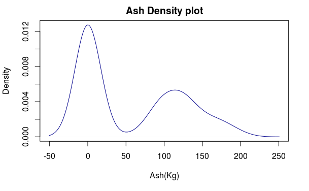

```r
plot(density(new$Ash), xlab='Ash(Kg)', main= 'Ash Density plot', col='darkblue')
```

```r
skewness(new$Ash)
```

```
[1] 0.489
```

```r
dip.test(new$Ash)
```

```
    Hartigans' dip test for unimodality / multimodality

data:  new$Ash
D = 0.09, p-value <2e-16
alternative hypothesis: non-unimodal, i.e., at least bimodal
```

Univariate analysis of “Water(Kg)” attribute

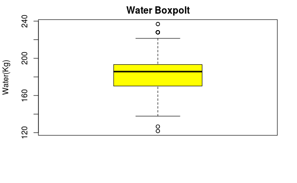

```r
boxplot( new$Water, ylab='Water(Kg)', main='Water Boxpolt',col = 'yellow' )
```

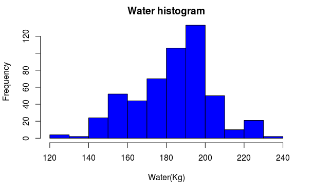

```r
hist(new$Water, xlab='Water(Kg)', main= 'Water histogram', col='blue')
```

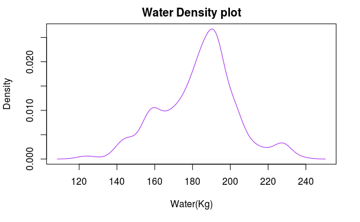

```r
plot(density(new$Water), xlab='Water(Kg)', main= 'Water Density plot', col='purple')
```

```r
skewness(new$Water)
```

```
[1] -0.16
```

```r
dip.test(new$Water)
```

```
    Hartigans' dip test for unimodality / multimodality

data:  new$Water
D = 0.04, p-value <2e-16
alternative hypothesis: non-unimodal, i.e., at least bimodal
```

Univariate analysis of “Superplasticizer(Kg)” attribute

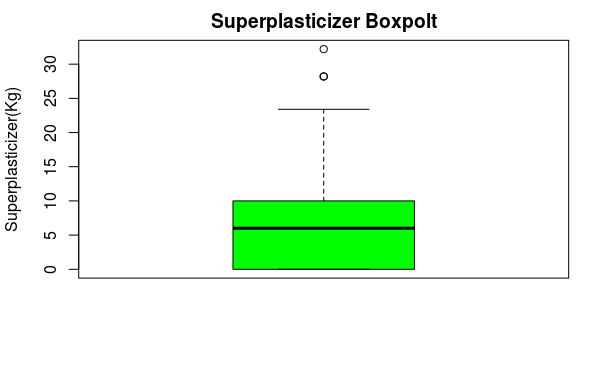

```r
boxplot( new$Superplasticizer, ylab='Superplasticizer(Kg)', main='Superplasticizer Boxpolt',col = 'green' )
```

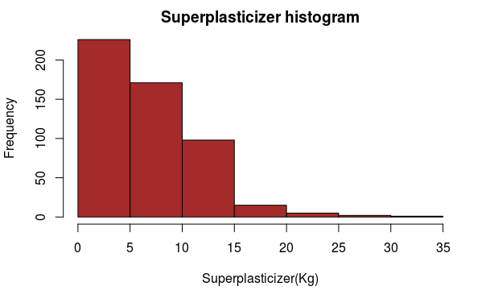

```r
hist(new$Superplasticizer, xlab='Superplasticizer(Kg)', main= 'Superplasticizer histogram', col='brown')
```

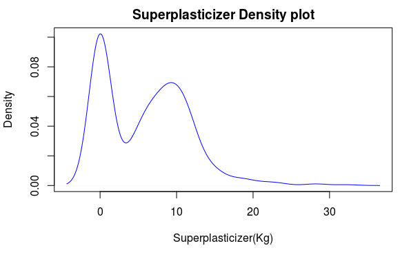

```r
plot(density(new$Superplasticizer), xlab='Superplasticizer(Kg)', main= 'Superplasticizer Density plot', col='blue')
```

```r
skewness(new$Superplasticizer)
```

```
[1] 0.759
```

```r
dip.test(new$Superplasticizer)
```

```
    Hartigans' dip test for unimodality / multimodality

data:  new$Superplasticizer
D = 0.08, p-value <2e-16
alternative hypothesis: non-unimodal, i.e., at least bimodal
```

Univariate analysis of “Coarse Aggregate(Kg)” attribute

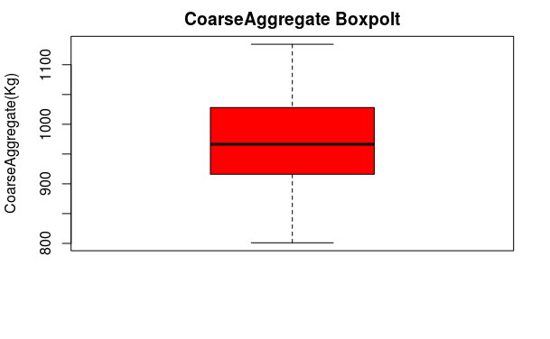

```r
boxplot( new$CoarseAggregate, ylab='CoarseAggregate(Kg)', main='CoarseAggregate Boxpolt',col = 'red' )
```

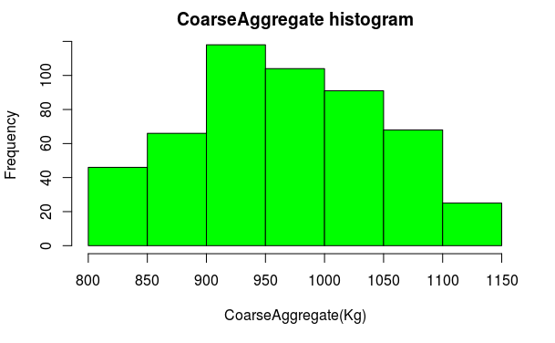

```r
hist(new$CoarseAggregate, xlab='CoarseAggregate(Kg)', main= 'CoarseAggregate histogram', col='green')
```

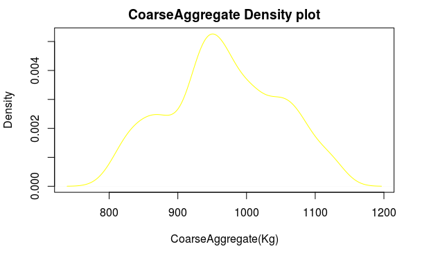

```r
plot(density(new$CoarseAggregate), xlab='CoarseAggregate(Kg)', main= 'CoarseAggregate Density plot', col='yellow')
```

```r
skewness(new$CoarseAggregate)
```

```
[1] 0.0057
```

```r
dip.test(new$CoarseAggregate)
```

```
    Hartigans' dip test for unimodality / multimodality

data:  new$CoarseAggregate
D = 0.02, p-value = 0.05
alternative hypothesis: non-unimodal, i.e., at least bimodal
```

Univariate analysis of “Fine Aggregate(Kg)” attribute

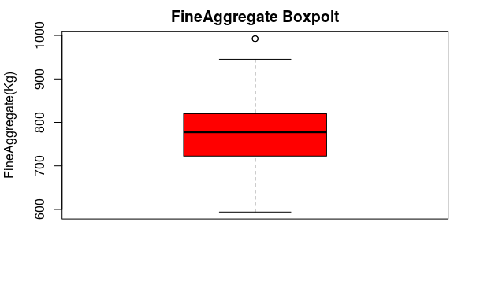

```r
boxplot( new$FineAggregate, ylab='FineAggregate(Kg)', main='FineAggregate Boxpolt',col = 'red' )
```

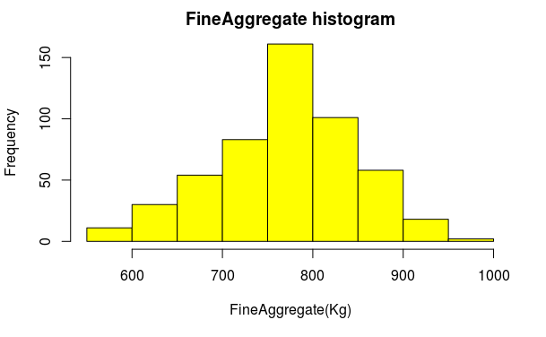

```r
hist(new$FineAggregate, xlab='FineAggregate(Kg)', main= 'FineAggregate histogram', col='yellow')
```

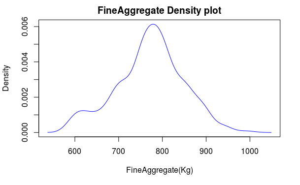

```r
plot(density(new$FineAggregate), xlab='FineAggregate(Kg)', main= 'FineAggregate Density plot', col='blue')
```

```r
skewness(new$FineAggregate)
```

```
[1] -0.192
```

```r
dip.test(new$FineAggregate)
```

```
    Hartigans' dip test for unimodality / multimodality

data:  new$FineAggregate
D = 0.02, p-value = 0.4
alternative hypothesis: non-unimodal, i.e., at least bimodal
```

Univariate analysis of “CompressiveStrength” attribute

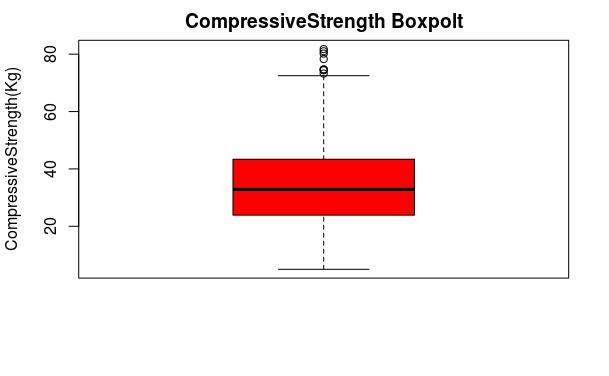

```r
boxplot( new$CompressiveStrength, ylab='CompressiveStrength(Kg)', main='CompressiveStrength Boxpolt',col = 'red' )
```

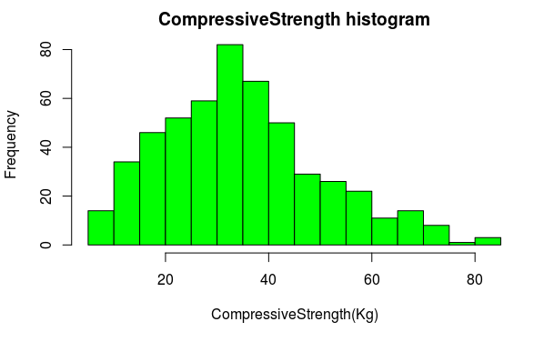

```r
hist(new$CompressiveStrength, xlab='CompressiveStrength(Kg)', main= 'CompressiveStrength histogram', col='green')
```

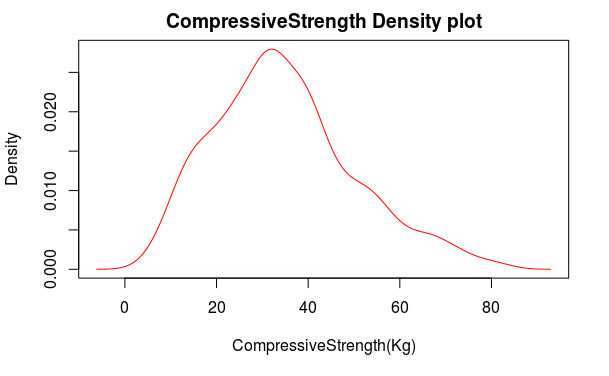

```r
plot(density(new$CompressiveStrength), xlab='CompressiveStrength(Kg)', main= 'CompressiveStrength Density plot', col='red')
```

```r
skewness(new$CompressiveStrength)
```

```
[1] 0.565
```

```r
dip.test(new$CompressiveStrength)
```

```
    Hartigans' dip test for unimodality / multimodality

data:  new$CompressiveStrength
D = 0.02, p-value = 0.3
alternative hypothesis: non-unimodal, i.e., at least bimodal
```

Transformed output applying BOX COX tranfermation

```r
#library('caret')
c<- caret:: BoxCoxTrans(new$CompressiveStrength)
print(c)
```

```
Box-Cox Transformation

518 data points used to estimate Lambda

Input data summary:
   Min. 1st Qu.  Median    Mean 3rd Qu.    Max.
    5.0    23.9    32.9    34.7    43.2    81.8

Largest/Smallest: 16.3
Sample Skewness: 0.563

Estimated Lambda: 0.5
```

```r
new$CompressiveStrength1=new$CompressiveStrength^0.5
```

Bivaraite analysis The covariance matrix generalizes the notion of variance to multiple dimensions. A scatter plot provides a graphical view of the relationship between two sets of attributes. Created new variable for Compressive Strength for Days (is factor) by mean.

```r
cor(new[,-8])
```

```
                       Cement     Slag      Ash   Water Superplasticizer
Cement                1.00000 -0.36681 -0.34834 -0.0881         -0.00642
Slag                 -0.36681  1.00000 -0.26992  0.1491         -0.00551
Ash                  -0.34834 -0.26992  1.00000 -0.2054          0.49829
Water                -0.08809  0.14913 -0.20537  1.0000         -0.57376
Superplasticizer     -0.00642 -0.00551  0.49829 -0.5738          1.00000
CoarseAggregate      -0.02356 -0.26016 -0.15718 -0.2721         -0.26325
FineAggregate        -0.19862 -0.30577  0.00757 -0.3940          0.14809
CompressiveStrength   0.49750  0.14843 -0.08083 -0.3094          0.32711
CompressiveStrength1  0.48761  0.15028 -0.06544 -0.2899          0.32215
                     CoarseAggregate FineAggregate CompressiveStrength
Cement                       -0.0236      -0.19862              0.4975
Slag                         -0.2602      -0.30577              0.1484
Ash                          -0.1572       0.00757             -0.0808
Water                        -0.2721      -0.39402             -0.3094
Superplasticizer             -0.2632       0.14809              0.3271
CoarseAggregate               1.0000      -0.13833             -0.1454
FineAggregate                -0.1383       1.00000             -0.2082
CompressiveStrength          -0.1454      -0.20817              1.0000
CompressiveStrength1         -0.1526      -0.22486              0.9890
                     CompressiveStrength1
Cement                             0.4876
Slag                               0.1503
Ash                               -0.0654
Water                             -0.2899
Superplasticizer                   0.3221
CoarseAggregate                   -0.1526
FineAggregate                     -0.2249
CompressiveStrength                0.9890
CompressiveStrength1               1.0000
```

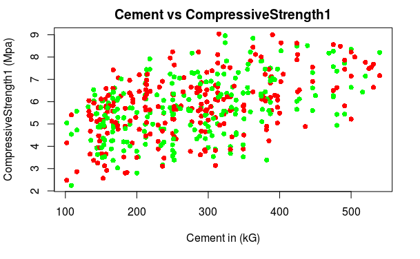

```r
plot(new$Cement,new$CompressiveStrength1,col=c('red','green'),pch=16, xlab = 'Cement in (kG)',ylab = 'CompressiveStrength1 (Mpa)', main = 'Cement vs CompressiveStrength1')
```

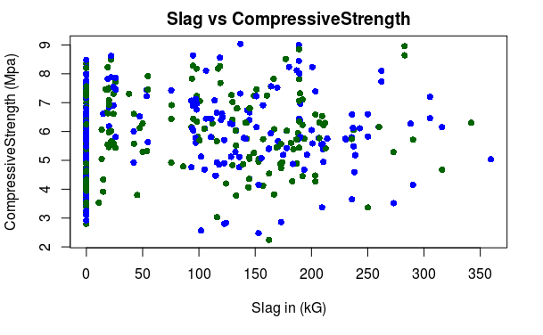

```r
plot(new$Slag,new$CompressiveStrength1,col=c('blue','darkgreen'),pch=16, xlab = 'Slag in (kG)',ylab = 'CompressiveStrength (Mpa)', main = 'Slag vs CompressiveStrength')
```

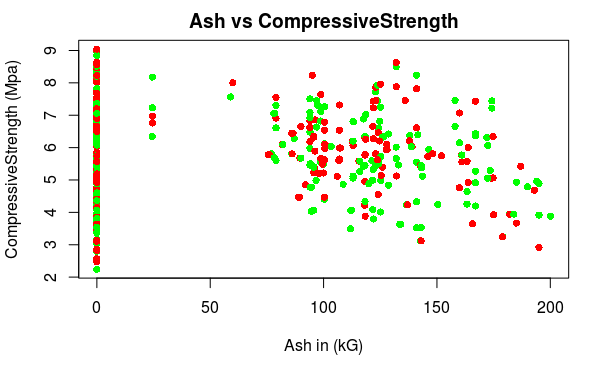

```r
plot(new$Ash,new$CompressiveStrength1,col=c('red','green'),pch=16, xlab = 'Ash in (kG)',ylab = 'CompressiveStrength (Mpa)', main = 'Ash vs CompressiveStrength')
```

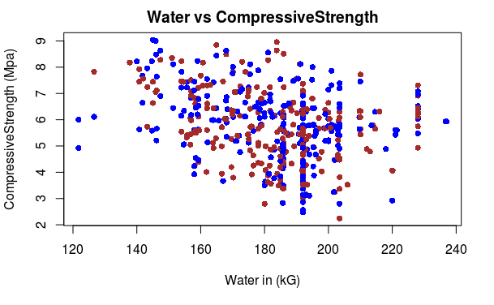

```r
plot(new$Water,new$CompressiveStrength1,col=c('blue','brown'),pch=16, xlab = 'Water in (kG)',ylab = 'CompressiveStrength (Mpa)', main = 'Water vs CompressiveStrength')
```

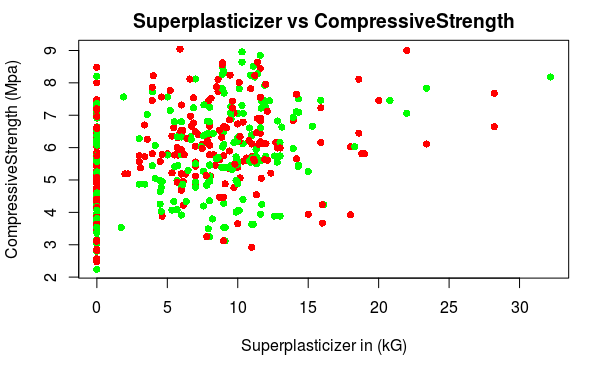

```r
plot(new$Superplasticizer,new$CompressiveStrength1,col=c('red','green'),pch=16, xlab = 'Superplasticizer in (kG)',ylab = 'CompressiveStrength (Mpa)', main = 'Superplasticizer vs CompressiveStrength')
```

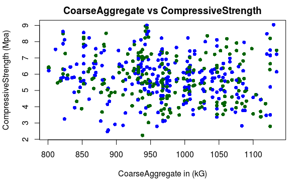

```r
plot(new$CoarseAggregate,new$CompressiveStrength1,col=c('blue','darkgreen'),pch=16, xlab = 'CoarseAggregate in (kG)',ylab = 'CompressiveStrength (Mpa)', main = 'CoarseAggregate vs CompressiveStrength')
```

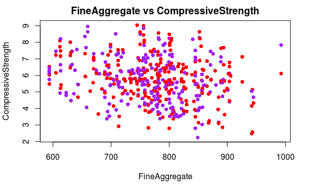

```r
plot(new$FineAggregate,new$CompressiveStrength1, col=c('red','purple'),pch=16, xlab='FineAggregate', ylab = 'CompressiveStrength',main='FineAggregate vs CompressiveStrength')
```

```r
ag=aggregate(new$CompressiveStrength1, by=list(new$Days),mean)
ag
```

| Group.1 | x |
| --- | --- |
| H | 6.82 |
| L | 4.60 |
| M | 5.87 |

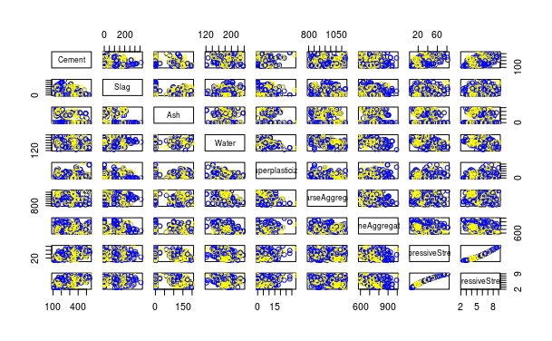

```r
pairs(new[,-8],col=c('blue','yellow'))
```

Data modeling lm function will give linear regression VIF is variance inflation factor

```r
# Building on train
new=new[,-9]
model=lm(CompressiveStrength1~., data=new)
summary(model)
```

```
Call:
lm(formula = CompressiveStrength1 ~ ., data = new)

Residuals:
    Min      1Q  Median      3Q     Max
-1.5400 -0.3492 -0.0061  0.3511  1.8758

Coefficients:
                  Estimate Std. Error t value Pr(>|t|)
(Intercept)       2.970948   2.153656    1.38    0.168
Cement            0.010740   0.000678   15.85  < 2e-16 ***
Slag              0.008448   0.000799   10.58  < 2e-16 ***
Ash               0.006207   0.000990    6.27  7.6e-10 ***
Water            -0.014104   0.003183   -4.43  1.1e-05 ***
Superplasticizer  0.004821   0.007622    0.63    0.527
CoarseAggregate   0.001428   0.000765    1.87    0.063 .
FineAggregate     0.001333   0.000872    1.53    0.127
DaysL            -2.218680   0.081566  -27.20  < 2e-16 ***
DaysM            -0.847070   0.071545  -11.84  < 2e-16 ***
---
Signif. codes:  0 ‘***’ 0.001 ‘**’ 0.01 ‘*’ 0.05 ‘.’ 0.1 ‘ ’ 1

Residual standard error: 0.583 on 508 degrees of freedom
Multiple R-squared:  0.809, Adjusted R-squared:  0.806
F-statistic:  239 on 9 and 508 DF,  p-value: <2e-16
```

```r
VIF(model)
```

```
[1] 5.24
```

```r
new1=new[,-c(5,6,7)]
model1=lm(CompressiveStrength1~., data=new1)
summary(model1)
```

```
Call:
lm(formula = CompressiveStrength1 ~ ., data = new1)

Residuals:
    Min      1Q  Median      3Q     Max
-1.5589 -0.3740 -0.0143  0.3633  1.8459

Coefficients:
             Estimate Std. Error t value Pr(>|t|)
(Intercept)  6.754259   0.296846   22.75   <2e-16 ***
Cement       0.009746   0.000313   31.14   <2e-16 ***
Slag         0.007252   0.000353   20.52   <2e-16 ***
Ash          0.004885   0.000492    9.94   <2e-16 ***
Water       -0.018987   0.001354  -14.02   <2e-16 ***
DaysL       -2.217646   0.081359  -27.26   <2e-16 ***
DaysM       -0.868896   0.070339  -12.35   <2e-16 ***
---
Signif. codes:  0 ‘***’ 0.001 ‘**’ 0.01 ‘*’ 0.05 ‘.’ 0.1 ‘ ’ 1

Residual standard error: 0.583 on 511 degrees of freedom
Multiple R-squared:  0.808, Adjusted R-squared:  0.805
F-statistic:  358 on 6 and 511 DF,  p-value: <2e-16
```

```r
VIF(model1)
```

```
[1] 5.2
```

Model validation R^2 will determine performation of model in predicted value.

```r
test=read.csv('test.csv')
#test=test[,-8]
str(test)
```

```
'data.frame':   222 obs. of  9 variables:
 $ Cement             : num  540 525 380 304 250 ...
 $ Slag               : num  0 0 0 76 167 ...
 $ Ash                : num  0 0 0 0 0 ...
 $ Water              : num  173 189 228 228 204 ...
 $ Superplasticizer   : num  0 0 0 0 0 ...
 $ CoarseAggregate    : num  1125 1125 932 932 978 ...
 $ FineAggregate      : num  613 613 670 670 694 ...
 $ Days               : Factor w/ 3 levels "H","L","M": 1 1 1 1 1 1 1 1 1 1 ...
 $ CompressiveStrength: num  71.8 62.6 53 52.4 47.7 ...
```

```r
test$CompressiveStrength1=test$CompressiveStrength^0.5
test=test[,-9]
pred=predict(model1,test)
sse=sum((pred-test$CompressiveStrength1)^2)
sst=sum((test$CompressiveStrength1-mean(test$CompressiveStrength1))^2)
e=(sse/sst)
rsquare=1-e
rsquare
```

```
[1] 0.804
```

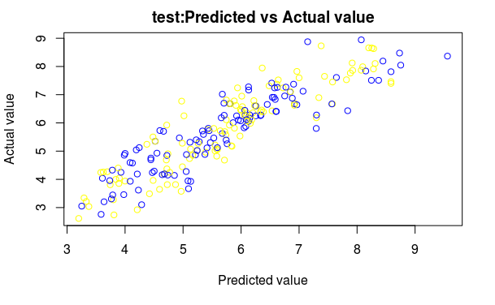

```r
#test
plot(pred,test$CompressiveStrength1, main='test:Predicted vs Actual value', xlab = 'Predicted value',ylab = 'Actual value', col=c('blue','yellow'))
```

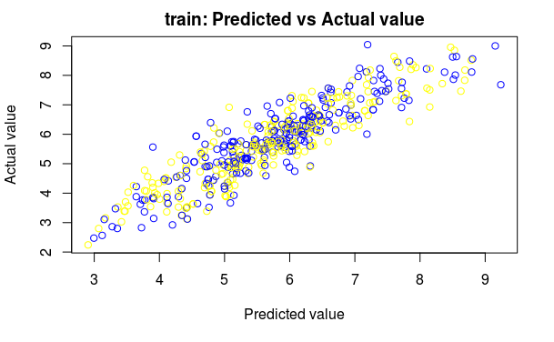

```r
#train
plot(fitted.values(model1),new1$CompressiveStrength1, main='train: Predicted vs Actual value', xlab = 'Predicted value',ylab = 'Actual value', col=c('blue','yellow'))
```

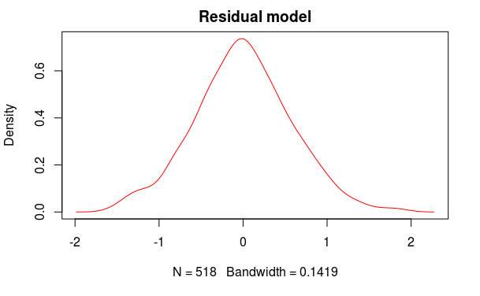

```r
#Model assumption
## Residual normality
plot(density(resid(model1)), main= 'Residual model', col='red')
```

```r
skewness(resid(model1))
```

```
[1] 0.0884
```

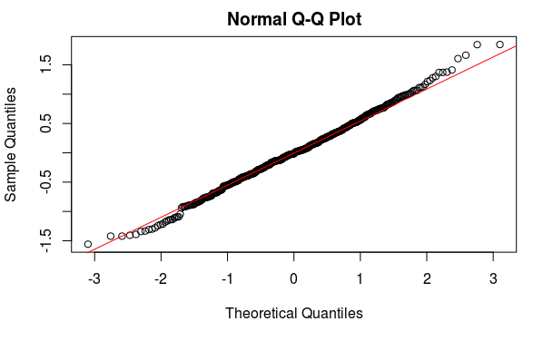

```r
qqnorm(resid(model1))
qqline(resid(model1),col='red')
```

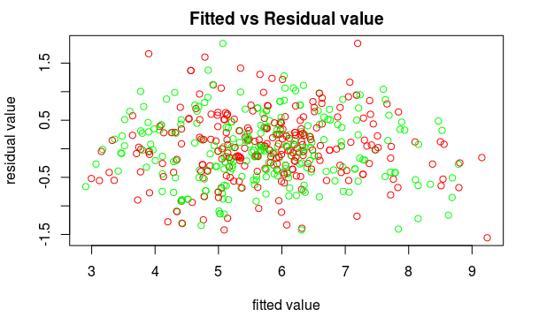

```r
# Residual homoscedasticity
plot(fitted.values(model1),resid(model1),main='Fitted vs Residual value',xlab='fitted value',ylab='residual value', col=c('red','green'))
```

homoscedacit

```r
#Breuch pagan test for homoscedacity
lmtest::bptest(model1)
```

```
    studentized Breusch-Pagan test

data:  model1
BP = 9, df = 6, p-value = 0.2
```

Residual liniarity

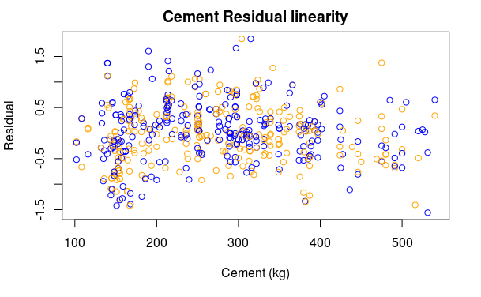

```r
#Residual liniarity
new1$resid=resid(model1)
plot(new$Cement,resid(model1),xlab = 'Cement (kg)',ylab = 'Residual', main = 'Cement Residual linearity',col=c('blue','orange'))
```

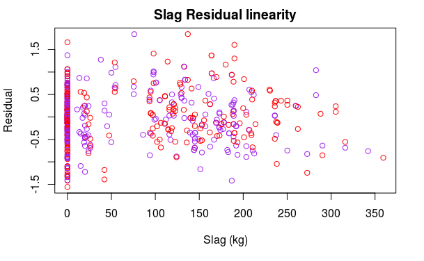

```r
plot(new$Slag,resid(model1),xlab = 'Slag (kg)',ylab = 'Residual', main = 'Slag Residual linearity',col=c('red','purple'))
```

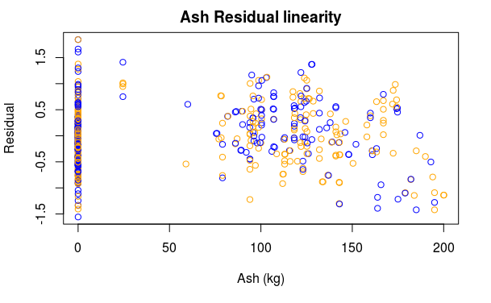

```r
plot(new$Ash,resid(model1),xlab = 'Ash (kg)',ylab = 'Residual', main = 'Ash Residual linearity',col=c('blue','orange'))
```

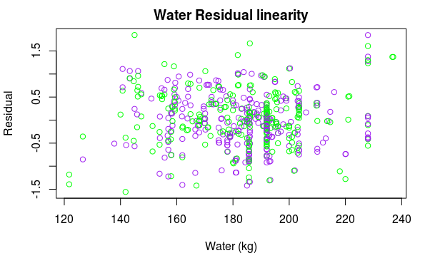

```r
plot(new$Water,resid(model1),xlab = 'Water (kg)',ylab = 'Residual', main = 'Water Residual linearity',col=c('green','purple'))
```

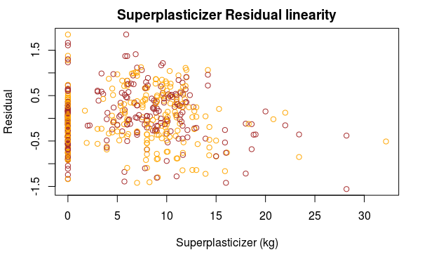

```r
plot(new$Superplasticizer,resid(model1),xlab = 'Superplasticizer (kg)',ylab = 'Residual', main = 'Superplasticizer Residual linearity',col=c('brown','orange'))
```

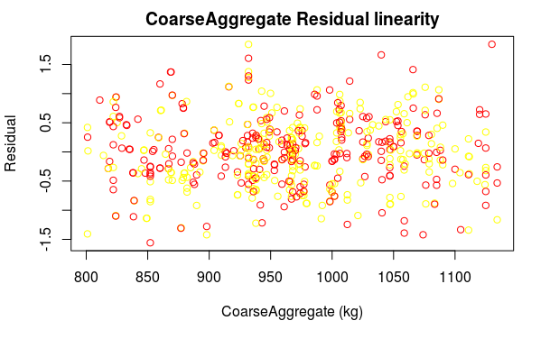

```r
plot(new$CoarseAggregate,resid(model1),xlab = 'CoarseAggregate (kg)',ylab = 'Residual', main = 'CoarseAggregate Residual linearity',col=c('red','yellow'))
```

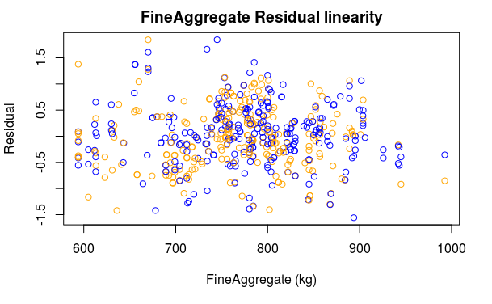

```r
plot(new$FineAggregate,resid(model1),xlab = 'FineAggregate (kg)',ylab = 'Residual', main = 'FineAggregate Residual linearity',col=c('blue','orange'))
```

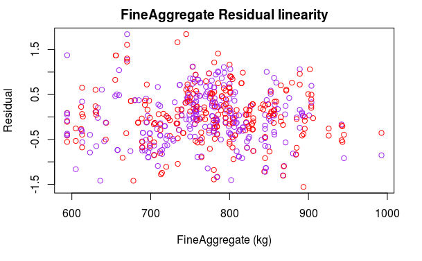

```r
plot(new$FineAggregate,resid(model1),xlab = 'FineAggregate (kg)',ylab = 'Residual', main = 'FineAggregate Residual linearity',col=c('red','purple'))
```

```
Analysis of Variance Table

Response: CompressiveStrength1
           Df Sum Sq Mean Sq F value  Pr(>F)
Cement      1    215   214.9   249.5 < 2e-16 ***
Slag        1    113   113.2   131.3 < 2e-16 ***
Ash         1     85    84.9    98.5 < 2e-16 ***
Water       1     49    49.0    56.9 2.1e-13 ***
Residuals 513    442     0.9
---
Signif. codes:  0 ‘***’ 0.001 ‘**’ 0.01 ‘*’ 0.05 ‘.’ 0.1 ‘ ’ 1
```

```
 As there is >1 explanatory variable, cross-validation
 predicted values for a fold are not a linear function
 of corresponding overall predicted values.  Lines that
 are shown for the different folds are approximate
```

```
fold 1
Observations in test set: 103
                         2    7    11    12    27   32   37     43    44    45
Predicted            7.542 7.50  7.06 5.542 4.981 5.24 5.20  5.254 5.582 5.700
cvpred               7.416 7.39  6.99 5.511 5.006 5.23 5.18  5.239 5.533 5.717
CompressiveStrength1 8.357 8.44  6.83 5.735 5.217 6.61 6.22  5.183 5.741 6.097
CV residual          0.941 1.05 -0.16 0.223 0.211 1.38 1.04 -0.056 0.208 0.379
                         48    50    52    54   58     68    69   72     82      86
Predicted            6.2315 5.094 5.188  4.94 5.15  5.860 4.675 4.88 5.5344  6.7528
cvpred               6.2031 5.122 5.214  5.00 5.13  5.852 4.669 4.90 5.5103  6.6994
CompressiveStrength1 6.2783 5.270 5.446  3.88 6.34  5.427 5.096 5.12 5.5540  6.6402
CV residual          0.0752 0.148 0.232 -1.11 1.21 -0.425 0.427 0.22 0.0438 -0.0592
                          88     98  107   109  110   111  115    120   125  126
Predicted             5.4888  4.344 5.66 4.848 5.76 5.217 5.41  4.932 7.274 7.10
cvpred                5.5063  4.390 5.67 4.839 5.71 5.197 5.38  4.919 7.190 7.03
CompressiveStrength1  5.4885  3.633 7.43 5.421 7.11 5.654 6.70  4.276 7.539 8.12
CV residual          -0.0179 -0.757 1.76 0.583 1.40 0.457 1.32 -0.643 0.349 1.09
                       132  135    145  151  156     169   173  179   185   186
Predicted            5.815 7.10  5.065 6.21 7.54  5.8924  4.55 6.48  7.62  5.20
cvpred               5.779 7.02  5.076 6.14 7.43  5.8913  4.56 6.42  7.59  5.18
CompressiveStrength1 6.293 8.12  4.850 7.23 7.82  5.8068  2.80 7.56  5.81  3.68
CV residual          0.514 1.10 -0.226 1.09 0.39 -0.0845 -1.76 1.15 -1.78 -1.50
                       188     191    198   205   206   208   211   225   228
Predicted            6.052  6.1192  7.355  4.45 4.784  4.30 5.769  4.86 6.941
cvpred               6.048  6.1037  7.259  4.51 4.767  4.36 5.748  4.90 6.839
CompressiveStrength1 6.213  6.0290  7.143  3.65 4.949  3.12 5.894  4.22 7.681
CV residual          0.165 -0.0747 -0.116 -0.86 0.183 -1.24 0.146 -0.68 0.842
                        232    234  236   246  266   280     291    292   300
Predicted             4.522 5.7762 5.04  5.43 7.37 6.430  4.9286  4.930  4.94
cvpred                4.514 5.7680 5.06  5.42 7.33 6.369  4.9161  4.930  4.96
CompressiveStrength1  3.703 5.8136 7.31  3.37 7.46 7.240  4.8772  4.558  4.78
CV residual          -0.811 0.0457 2.25 -2.05 0.13 0.871 -0.0389 -0.372 -0.18
                        302  308  312   341   343  344  347  348   354   358   360
Predicted             5.537 6.12 5.89  4.88 6.253 5.66 4.81 7.11 5.380 5.383 4.974
cvpred                5.537 6.05 5.89  4.86 6.213 5.67 4.82 7.06 5.350 5.374 4.985
CompressiveStrength1  5.056 8.18 6.45  2.83 6.456 7.02 6.10 8.23 5.648 5.497 5.713
CV residual          -0.482 2.13 0.56 -2.03 0.243 1.35 1.29 1.17 0.298 0.124 0.728
                       363   373  380    382    385    387    388    393  394   395
Predicted             4.99 5.084 7.50  5.423  4.367  5.699  4.945  5.956 5.01 7.343
cvpred                4.97 5.076 7.45  5.508  4.364  5.709  4.926  5.910 5.00 7.303
```

[output cut: 248 more lines]

```
Predicted             5.160 6.11 5.310  4.834 5.390  4.220  4.9327  4.383  5.182
cvpred                5.095 6.04 5.243  4.794 5.408  4.150  4.8985  4.357  5.146
CompressiveStrength1  4.399 7.45 6.205  4.360 5.643  3.490  4.8728  4.188  4.868
CV residual          -0.695 1.41 0.962 -0.434 0.234 -0.659 -0.0257 -0.169 -0.278
                         467   479    482    493   501    506
Predicted             7.1194 4.577  7.801  7.473 4.887  5.810
cvpred                7.1549 4.552  7.837  7.580 4.867  5.786
CompressiveStrength1  7.1202 4.928  7.565  7.453 5.570  5.384
CV residual          -0.0347 0.376 -0.272 -0.127 0.703 -0.401

Sum of squares = 97.4    Mean square = 0.95    n = 103

Overall (Sum over all 103 folds)
   ms
0.871
```

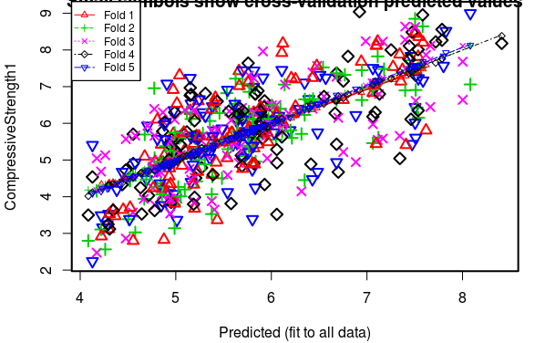

```r
# Model validation
res = cv.lm(data=new, (form.lm =CompressiveStrength1~Cement+Slag+Ash+Water ),m=5,dots=FALSE,seed=29, plotit = c("Observed", "Residual"), legend.pos="topleft")
```

K fold summary

```r
#k fold summary
k=5
new$id <- sample(1:k, nrow(new), replace = TRUE)
list <- 1:k
for(i in 1:k){
  trainset <- subset(new,id %in% list[-i])
  testset <- subset(new,id %in% c(i))
  model <- lm(trainset$CompressiveStrength1~trainset$Cement+trainset$Slag+trainset$Ash+trainset$Water)
  predictions <- predict(model,testset[-c(4,5)])
  a <- summary(model)
   rmse <- sqrt(mean(model$residuals^2))
   print(model$coefficients)
   print(a$r.squared)
   print(rmse)
 }
```

```
'newdata' had 117 rows but variables found have 401 rows
```

```
    (Intercept) trainset$Cement   trainset$Slag    trainset$Ash  trainset$Water
        4.79876         0.01005         0.00840         0.00592        -0.01489
[1] 0.53
[1] 0.899
```

```
'newdata' had 95 rows but variables found have 423 rows
```

```
    (Intercept) trainset$Cement   trainset$Slag    trainset$Ash  trainset$Water
        5.03891         0.01006         0.00813         0.00575        -0.01651
[1] 0.522
[1] 0.925
```

```
'newdata' had 78 rows but variables found have 440 rows
```

```
    (Intercept) trainset$Cement   trainset$Slag    trainset$Ash  trainset$Water
        5.05837         0.00940         0.00795         0.00579        -0.01546
[1] 0.477
[1] 0.922
```

```
'newdata' had 108 rows but variables found have 410 rows
```

```
    (Intercept) trainset$Cement   trainset$Slag    trainset$Ash  trainset$Water
        5.09594         0.01006         0.00837         0.00637        -0.01699
[1] 0.519
[1] 0.926
```

```
'newdata' had 120 rows but variables found have 398 rows
```

```
    (Intercept) trainset$Cement   trainset$Slag    trainset$Ash  trainset$Water
        4.91415         0.01035         0.00826         0.00698        -0.01659
[1] 0.512
[1] 0.939
```

```r
# #Actual Vs. Fitted value
plot(fitted.values(model),new$CompressiveStrength1,col=c("red","blue"),main="Actual value vs. Fitted value")#Actual Vs. fitted
```

```
Error in xy.coords(x, y, xlabel, ylabel, log) :
  'x' and 'y' lengths differ
```